# Lab 2 - Classification and Regression

### Citations are represented with prefix şş followed by reference link.

Sanjay Pillay, Huy Hoang Nguyen, Hao Wang, Wailun Chung

## Table of Contents:

### 0. Introduction and Business Understanding

### 1. Data Preparation - Part I

### 2. Data Preparation - Part II

### 3. Modeling and Evaluation 1

### 4. Modeling and Evaluation 2

### 5. Modeling and Evaluation 3

### 6. Modeling and Evaluation 4

### 7. Modeling and Evaluation 5

### 8. Modeling and Evaluation 6

### 9. Deployment

### 10. Exceptional Work

### 11. Conclusion and Discussion

# 0. Introduction and Business Understanding

## Introduction

In this lab, we will use different machine learning algorithms for our two main tasks documented below.

1. Run predictive model to predict wage from players abilities (**regression models**). We will select some features to run regression models. Also, we will try running LDA and regression model. To measure the effectiveness, we will use RMSE, MAE and R squared.
2. Run classification model to classify players (**classification models**) position from the players ability. To validate our models, we will use accuracy, precision, F1 score and ROC.

We carry over the Business Understanding and Data Preparation from Lab 1. More information related to Visualization and Data Preprocessing can be found in Lab 1.

## Business Understanding

Kaggle dataset (https://www.kaggle.com/stefanoleone992/fifa-20-complete-player-dataset) *players_20.csv* is used in this lab. The dataset provides detailed information of all the **soccer players statistics** in various clubs of major soccer leagues in the world. The data is originally from the FIFA soccer game created by EA sports. This game estimates the abilities of the actual players and built the game according to the data. And the Kaggle dataset is scraped from www.sofifa.com, where the gaming data is collected. The data we used is last updated on Sept 19th 2019.

The dataset is important because the abilities of players is estimated from the actual players. FIFA is a very popular game and EA Sports is one of the largest sport video game developer. The player abilities estimate is quite accurate. Therefore, useful knowledge can be mined from the data for analyzing variety problems in the soccer industry. For example, wage analysis, player analysis, training strategy, budget analysis, sport gambling strategy plan can be performed using this dataset. Soccer has been a big industry which the market size is estimated to worth $488 billion in 2018 according to the Business Wire.

⏫ Table of Contents

şş Image captured from https://en.wikipedia.org/wiki/FIFA_20

[figure not shown]

# 1. Data Preparation Part I

In this subsection, we deal with missing values, converting data types to appropriate ones. We will also divide the soccers players into 4 groups meaningfully as Defending (DEF), Forward (FWD), Midfield (MID) and Goal Keeper (GK) to learn from existing dataset to predict new players potential positions based on their skillset. We will come with our final cleaned dataset for our regression and classification task's.

Note: We will reserve the data scaling to Part 2 subsection while preparing the test/train dataset.

```python
#All Python module imports
#https://pandas.pydata.org/docs/user_guide/index.html#user-guide
import pandas as pd #Pandas Dataframe module

import numpy as np
from math import pi
#scikit learn
#https://scikit-learn.org/stable/modules/classes.html#module-sklearn.linear_model
import sklearn as sl


import pycountry
import plotly.express as px

#https://seaborn.pydata.org
import seaborn as sns
import matplotlib.pyplot as plt

# os calls
import os

#Module for formating table for documentation
#https://pypi.org/project/tabulate/
from tabulate import tabulate

from IPython.display import display, Markdown

#Interactive mode
from IPython.core.interactiveshell import InteractiveShell
InteractiveShell.ast_node_interactivity = "all"
from IPython.display import Image

##minilab imports
from sklearn.model_selection import GridSearchCV as gridcv
from sklearn import preprocessing
from sklearn.feature_selection import SelectKBest, chi2
from sklearn.model_selection import StratifiedShuffleSplit
from sklearn.preprocessing import StandardScaler
from sklearn.linear_model import LogisticRegression
from sklearn import metrics as mt
from sklearn.metrics import plot_confusion_matrix
from sklearn.metrics import classification_report
from sklearn.svm import SVC
from sklearn.decomposition import PCA
from sklearn.metrics import confusion_matrix
from sklearn.metrics import f1_score, accuracy_score
```

Due to the large number of features we have created a csv file that will serve as a metadata file as follows  
1) File location: ../data/fifa20/data_desc.csv  
2) The Name column as the exact name that is in our original dataset file and we will use this to load the file.  
3) Description: The team has filled up the description of each feature describing it.  
4) Variable_cat: We use this to categorise related features for example 'Position' indicates all the features related to various position attirbutes.  
Using a metadata makes it easy in case we want to ignore certain attributes that are not relavant for our analysis by marking it as Ignore.

```python
##Globally set seed
np.random.seed(45)

#Read data explanation csv file maintained by project team
%time df_desc = pd.read_csv('../data/fifa20/data_desc.csv',usecols=['Name','Description','Statistics','Variable_cat'])
#display(Markdown(df_desc[['Name','Description','Variable_cat']].to_markdown()))

#All positional attributes, These are various field positions a players can playin with a players statisics in
#that position. These attributes are only for non-goalkeepers.
df_position_attr = df_desc[df_desc['Variable_cat']=='Position']['Name']

#All goalKeeper only attributes
df_gk_attr = df_desc[df_desc['Variable_cat']=='GK']['Name']

#All Technical attributes. Non GK players primary technical skills such as dribbling, curving etc.
df_technical_attr = df_desc[df_desc['Variable_cat']=='Technical']['Name']

#All mental attributes for all players
df_mental_attr = df_desc[df_desc['Variable_cat']=='Mental']['Name']

#All Attacking attributes  for all players
df_attacking_attr = df_desc[df_desc['Variable_cat']=='Attacking']['Name']

#All general Skill category attributes  for all players
df_skill_attr = df_desc[df_desc['Variable_cat']=='Skill']['Name']

#All Movement attributes  for all players
df_movement_attr = df_desc[df_desc['Variable_cat']=='Movement']['Name']

#All Power attributes  for all players
df_power_attr = df_desc[df_desc['Variable_cat']=='Power']['Name']

#All Defending attributes  for all players
df_defending_attr = df_desc[df_desc['Variable_cat']=='Defending']['Name']

# Sample code for future use to include adhoc columns
# Get all columns of player posiotion, you can do same for technical, Physical, GK etc
## l=df_gk_attr.append(pd.Series(['short_name','age','club']))
## df_gkplus_list from main object df_players = df_players[l]
```

```
Wall time: 440 ms
```

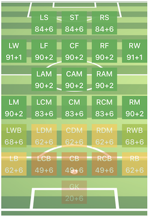

This image helps us understand various positions that a soccer players is assigned during a game. The feature **player_positions** represents multiple positions that a player can play in with a comma seperate value, the very first item in that list has a preferred field position of the player. The **team_position** is the current positon that the player is being used in the team. For our analysis we will use the players preferred positon.

```python
#Data mining read csv file
#Using data set: https://www.kaggle.com/stefanoleone992/fifa-20-complete-player-dataset#players_15.csv
#we will read only data we are intrested in
cols_to_read = df_desc['Name'].loc[df_desc.Variable_cat != 'Ignore']
%time df_players = pd.read_csv('../data/fifa20/players_20.csv',usecols=cols_to_read)
```

```
Wall time: 535 ms
```

The feature player_positions has the comma seperated list of a players prefered positions in order of their most prefered one being first. We will use the first position as the players position for our analysis and introduce a new column to hold this.

```python
df_players['preferred_position'] = df_players.player_positions.str.split(',').apply(lambda x: x[0])
```

#### team_postion

We see the team_position has 241 empty values. Since we do not intent to use team_position nor nation_positon in our analysis, we will drop it.

```python
df_players = df_players.drop(columns=['nation_position','team_position'])
```

#### Categorizing to four player positions

1. Defending (DEF)
2. Forward (FWD)
3. Midfield (MID)
4. Goal Keeper (GK)

We will use this later to predict player positions

```python
#df_players.preferred_position.value_counts()
df_players['preferred_position_cat'] = df_players.preferred_position.map({

        'CB': 'DEF',
        'ST': 'FWD',
        'CM': 'MID',
        'GK': 'GK',
       'CDM': 'DEF',
        'RB': 'DEF',
        'LB': 'DEF',
       'CAM': 'FWD',
        'RM': 'MID',
        'LM': 'MID',
        'LW': 'FWD',
        'RW': 'FWD',
        'CF': 'FWD',
       'LWB': 'DEF',
        'RWB': 'DEF'
    })
```

```python
df_players.preferred_position_cat.value_counts()
```

```
DEF    7362
FWD    4588
MID    4292
GK     2036
Name: preferred_position_cat, dtype: int64
```

#### Wages

As seen on analysis in the above section, there are 240 players with 0 wages_eur and 250 with with 0 value_eur, we will fill these with median values for our predictions.

```python
# 1. wages, The fields wage_eur and value_eur have about 240 and 250 vales respectively set to 0 (Analyzed in
# section B), we will set these values to the respective median values
#df_players['wage_eur'].median()
df_players['wage_eur'].replace(0,df_players['wage_eur'].median(), inplace=True)
```

```python
#df_players['value_eur'].median()
df_players['value_eur'].replace(0,df_players['value_eur'].median(), inplace=True)
df_players.shape
```

```
(18278, 87)
```

```python
df_players['wage_eur'].value_counts(bins=7)
```

```
(435.999, 81571.429]        18034
(81571.429, 162142.857]       176
(162142.857, 242714.286]       47
(242714.286, 323285.714]       13
(323285.714, 403857.143]        5
(403857.143, 484428.571]        2
(484428.571, 565000.0]          1
Name: wage_eur, dtype: int64
```

We will remove three outliner records who are paid extremly high (This analysis was done in Lab1). We chose to do this to avoid fitting our model to this outliners in regression.

```python
df_players.drop(df_players[df_players['wage_eur'] > 400000].index, inplace = True)
df_players = df_players.reset_index()
df_players.shape
```

```
(18275, 88)
```

#### Body type

```python
df_players['body_type'].replace({'Shaqiri': 'Normal', 'Akinfenwa': 'Normal'
                                , 'C. Ronaldo': 'Normal', 'PLAYER_BODY_TYPE_25': 'Normal'
                                , 'Neymar': 'Normal', 'Courtois': 'Normal','Messi':'Normal'}, inplace=True)
#df_players['body_type'].value_counts()
```

#### Refactor position features [Object to discrete]

The position features inculdes year over improvement / decrement. For example a player in st (Striker) position with a value of 89+2 is basically 89 with an increase (- would indicate decrease) of 2 from last year. Since we will not be doing any year over analysis, we will remove the suffix for these columns = ['ls','st','rs','lw','lf','cf','rf', 'rw','lam','cam','ram', 'lm','lcm','cm','rcm','rm','lwb','ldm', 'cdm','rdm', 'rwb','lb','lcb', 'cb','rcb','rb']

```python
# 4. Refactor position features based on bullet 1 above to remove the +/- incriment/decriment and preseve
# the current years score
df_players1 = df_players[df_position_attr].apply(lambda x: x.str.slice(start=0,stop=2),
                          axis=1, result_type='broadcast')
df_players[df_position_attr] = df_players1
```

#### Dealing with missing values

The player positional features mentioned above and the skills features ['pace','shooting', 'passing','dribbling', 'defending','physic'] have a total of 2036 missing values. We see that all of them are categorized to play in the GK position (player_positions="GK", Goal Keeper). We will set these values to zero.

#### Goal Keeper specific attributes

The following features ['gk_diving','gk_handling','gk_kicking','gk_reflexes', 'gk_speed','gk_positioning'] are specific to goalkeepers. We see a total of 16242 mising values, which corrosponds to the non goalkeeper or regular positional players. We will set these values to zero. Also there are duplicate columns representing these same attributes which we will ignore ['goalkeeping_diving', 'goalkeeping_handling', 'goalkeeping_kicking', 'goalkeeping_positioning', 'goalkeeping_reflexes']

```python
df_players.info(verbose=True, null_counts=True)
```

```
<class 'pandas.core.frame.DataFrame'>
RangeIndex: 18275 entries, 0 to 18274
Data columns (total 88 columns):
 #   Column                      Non-Null Count  Dtype
---  ------                      --------------  -----
 0   index                       18275 non-null  int64
 1   sofifa_id                   18275 non-null  int64
 2   short_name                  18275 non-null  object
 3   age                         18275 non-null  int64
 4   dob                         18275 non-null  object
 5   height_cm                   18275 non-null  int64
 6   weight_kg                   18275 non-null  int64
 7   nationality                 18275 non-null  object
 8   club                        18275 non-null  object
 9   overall                     18275 non-null  int64
```

[output cut: 80 more lines]

```python
# 5, 6. we will set all the other missing variables to 0 as explained above in bullet 4 & 5
df_players.fillna(0, inplace=True)
```

#### Data type conversion

We will first convert our continuous features.

```python
# changing the continuous values to be float64
continuous_features = ['height_cm','weight_kg','value_eur', 'wage_eur']
df_players[continuous_features] = df_players[continuous_features].astype(np.float64)
```

sofifa_id is converted to object as it is a nominal

```python
df_players['sofifa_id'] = df_players['sofifa_id'].astype(np.object)
```

We will convert object features that are discrete to integer

```python
#change the position features from object to int64 as they we manipulated to remove +/- based on step 1
df_players[df_position_attr] = df_players[df_position_attr].astype(np.int64)
#df_players.info(verbose=True, null_counts=True)
```

#### Onehot Encoding positions

As we will be using the players prefered position for the regression modles to predict players wages we will one hot encode the position. We will drop one of the columns of the encoded set.

```python
from sklearn.preprocessing import OneHotEncoder

# we will create the encoder and drop the first column
enc = OneHotEncoder(handle_unknown='error', drop='first').fit(df_players[['preferred_position']])
df_players.shape
enc.categories_
X = enc.transform(df_players[['preferred_position']]).toarray()
X.shape
#Check the categories
enc.inverse_transform([[0, 0, 0, 0, 0,0,0,0,0,0,0,0,0,0]])

## Add back to df
p = pd.DataFrame(X)
p.shape
## We will use this dataframe later to add it to the regression classification set
```

```
(18275, 88)
```

```
[array(['CAM', 'CB', 'CDM', 'CF', 'CM', 'GK', 'LB', 'LM', 'LW', 'LWB',
        'RB', 'RM', 'RW', 'RWB', 'ST'], dtype=object)]
```

```
(18275, 14)
```

```
array([['CAM']], dtype=object)
```

```
(18275, 14)
```

```python
df_players.info(verbose=True, null_counts=True)
```

```
<class 'pandas.core.frame.DataFrame'>
RangeIndex: 18275 entries, 0 to 18274
Data columns (total 88 columns):
 #   Column                      Non-Null Count  Dtype
---  ------                      --------------  -----
 0   index                       18275 non-null  int64
 1   sofifa_id                   18275 non-null  object
 2   short_name                  18275 non-null  object
 3   age                         18275 non-null  int64
 4   dob                         18275 non-null  object
 5   height_cm                   18275 non-null  float64
 6   weight_kg                   18275 non-null  float64
 7   nationality                 18275 non-null  object
 8   club                        18275 non-null  object
 9   overall                     18275 non-null  int64
```

[output cut: 80 more lines]

### **Reducing dataset and scaling them**

#### Classification Task

In Lab 1 analysis, we identified our regressor variables that we plan to use for our two tasks. There are a total of 31 features which include the players mental, attacking, skills, movements, defending, power, height and weight attributes. We will reduce the dataset as follows.

1. Classifying players' position: In addition to the above mentioned 31 features we will inclue the feature preferred_position_cat that identifies the players on the four positional categories.

```python
#create a list of columns that we will include in our final dataset for our tasks 1
l=df_mental_attr.append(df_attacking_attr).append(df_skill_attr).append(df_movement_attr).append(df_power_attr).append(df_defending_attr)
l=l.append(pd.Series(['height_cm','weight_kg']))

df_players_clf = df_players[l].copy()
players_clf_X = df_players_clf[l].values
players_clf_y = df_players['preferred_position_cat'].values

##Scale the transformed data
scl_obj = StandardScaler()
scl_obj.fit(players_clf_X)
X_players_clf_scaled = scl_obj.transform(players_clf_X)
df_players_clf.shape
```

```
StandardScaler()
```

```
(18275, 31)
```

#### **Regression Task**

1. Regression of player wages: In addition to the above mentioned 31 features we will include the onehotencoded set of columns of a players primary position (this is different from the four positianle categories we use for classification)

```python
#create a list of columns that we will include in our final dataset for our task 2

l=df_mental_attr.append(df_attacking_attr).append(df_skill_attr).append(df_movement_attr).append(df_power_attr).append(df_defending_attr)
l=l.append(pd.Series(['age','international_reputation','value_eur','overall','height_cm','weight_kg',
                     ]))

df_players_reg = df_players[l].copy()
df_players_reg.shape
# Adding the one hot encoded position dataframe generated earlier
df_players_reg = pd.concat([df_players_reg, p], axis=1)
df_players_reg.shape

players_reg_X = df_players_reg.values
players_reg_y = df_players['wage_eur'].values

##Scale the transformed data
scl_obj = StandardScaler()
scl_obj.fit(players_reg_X)
X_players_reg_scaled = scl_obj.transform(players_reg_X)
players_reg_X.shape
players_reg_y.shape
X_players_reg_scaled.shape
```

```
(18275, 35)
```

```
(18275, 49)
```

```
StandardScaler()
```

```
(18275, 49)
```

```
(18275,)
```

```
(18275, 49)
```

```python
df_players_reg.info(verbose=True)
```

```
<class 'pandas.core.frame.DataFrame'>
RangeIndex: 18275 entries, 0 to 18274
Data columns (total 49 columns):
 #   Column                      Non-Null Count  Dtype
---  ------                      --------------  -----
 0   mentality_aggression        18275 non-null  int64
 1   mentality_interceptions     18275 non-null  int64
 2   mentality_positioning       18275 non-null  int64
 3   mentality_vision            18275 non-null  int64
 4   mentality_penalties         18275 non-null  int64
 5   mentality_composure         18275 non-null  int64
 6   attacking_crossing          18275 non-null  int64
 7   attacking_finishing         18275 non-null  int64
 8   attacking_heading_accuracy  18275 non-null  int64
 9   attacking_short_passing     18275 non-null  int64
```

[output cut: 41 more lines]

⏫ Table of Contents

# 2. Data Preparation Part 2

### Classification Task dataset summary

```python
df_players_clf.shape
df_players_clf.describe()
df_players_clf.info(verbose=True, null_counts=True)
```

```
(18275, 31)
```

|  | mentality_aggression | mentality_interceptions | mentality_positioning | mentality_vision | mentality_penalties | mentality_composure | attacking_crossing | attacking_finishing | attacking_heading_accuracy | attacking_short_passing | ... | power_shot_power | power_jumping | power_stamina | power_strength | power_long_shots | defending_marking | defending_standing_tackle | defending_sliding_tackle | height_cm | weight_kg |
| --- | --- | --- | --- | --- | --- | --- | --- | --- | --- | --- | --- | --- | --- | --- | --- | --- | --- | --- | --- | --- | --- |
| count | 18275.000000 | 18275.000000 | 18275.000000 | 18275.000000 | 18275.000000 | 18275.000000 | 18275.000000 | 18275.000000 | 18275.000000 | 18275.000000 | ... | 18275.000000 | 18275.000000 | 18275.000000 | 18275.000000 | 18275.000000 | 18275.000000 | 18275.000000 | 18275.000000 | 18275.000000 | 18275.000000 |
| mean | 55.742271 | 46.381833 | 50.065280 | 53.604049 | 48.377729 | 58.522955 | 49.712722 | 45.582763 | 52.218003 | 58.743201 | ... | 58.176854 | 64.926840 | 62.886457 | 65.234036 | 46.806019 | 46.851382 | 47.642900 | 45.610178 | 181.362845 | 75.276170 |
| std | 17.319396 | 20.777028 | 19.588211 | 13.949535 | 15.703083 | 11.873086 | 18.321503 | 19.587474 | 17.427119 | 14.675994 | ... | 13.321638 | 11.932761 | 16.017422 | 12.535457 | 19.316193 | 20.091966 | 21.586419 | 21.217659 | 6.756701 | 7.048042 |
| min | 9.000000 | 3.000000 | 2.000000 | 9.000000 | 7.000000 | 12.000000 | 5.000000 | 2.000000 | 5.000000 | 7.000000 | ... | 14.000000 | 19.000000 | 12.000000 | 20.000000 | 4.000000 | 1.000000 | 5.000000 | 3.000000 | 156.000000 | 50.000000 |
| 25% | 44.000000 | 25.000000 | 39.000000 | 44.000000 | 39.000000 | 51.000000 | 38.000000 | 30.000000 | 44.000000 | 54.000000 | ... | 48.000000 | 58.000000 | 56.000000 | 58.000000 | 32.000000 | 29.000000 | 27.000000 | 24.000000 | 177.000000 | 70.000000 |
| 50% | 58.000000 | 52.000000 | 55.000000 | 55.000000 | 49.000000 | 60.000000 | 54.000000 | 49.000000 | 56.000000 | 62.000000 | ... | 59.000000 | 66.000000 | 66.000000 | 66.000000 | 51.000000 | 52.000000 | 55.000000 | 52.000000 | 181.000000 | 75.000000 |
| 75% | 69.000000 | 64.000000 | 64.000000 | 64.000000 | 60.000000 | 67.000000 | 64.000000 | 62.000000 | 64.000000 | 68.000000 | ... | 68.000000 | 73.000000 | 74.000000 | 74.000000 | 62.000000 | 64.000000 | 66.000000 | 64.000000 | 186.000000 | 80.000000 |
| max | 95.000000 | 92.000000 | 93.000000 | 94.000000 | 92.000000 | 95.000000 | 93.000000 | 94.000000 | 93.000000 | 92.000000 | ... | 95.000000 | 95.000000 | 97.000000 | 97.000000 | 92.000000 | 94.000000 | 92.000000 | 90.000000 | 205.000000 | 110.000000 |

8 rows × 31 columns

```
<class 'pandas.core.frame.DataFrame'>
RangeIndex: 18275 entries, 0 to 18274
Data columns (total 31 columns):
 #   Column                      Non-Null Count  Dtype
---  ------                      --------------  -----
 0   mentality_aggression        18275 non-null  int64
 1   mentality_interceptions     18275 non-null  int64
 2   mentality_positioning       18275 non-null  int64
 3   mentality_vision            18275 non-null  int64
 4   mentality_penalties         18275 non-null  int64
 5   mentality_composure         18275 non-null  int64
 6   attacking_crossing          18275 non-null  int64
 7   attacking_finishing         18275 non-null  int64
 8   attacking_heading_accuracy  18275 non-null  int64
 9   attacking_short_passing     18275 non-null  int64
```

[output cut: 23 more lines]

### Regression Task dataset summary

```python
df_players_reg.shape
df_players_reg.describe()
df_players_reg.info(verbose=True, null_counts=True)
```

```
(18275, 49)
```

|  | mentality_aggression | mentality_interceptions | mentality_positioning | mentality_vision | mentality_penalties | mentality_composure | attacking_crossing | attacking_finishing | attacking_heading_accuracy | attacking_short_passing | ... | 4 | 5 | 6 | 7 | 8 | 9 | 10 | 11 | 12 | 13 |
| --- | --- | --- | --- | --- | --- | --- | --- | --- | --- | --- | --- | --- | --- | --- | --- | --- | --- | --- | --- | --- | --- |
| count | 18275.000000 | 18275.000000 | 18275.000000 | 18275.000000 | 18275.000000 | 18275.000000 | 18275.000000 | 18275.000000 | 18275.000000 | 18275.000000 | ... | 18275.000000 | 18275.000000 | 18275.000000 | 18275.000000 | 18275.000000 | 18275.000000 | 18275.000000 | 18275.000000 | 18275.000000 | 18275.000000 |
| mean | 55.742271 | 46.381833 | 50.065280 | 53.604049 | 48.377729 | 58.522955 | 49.712722 | 45.582763 | 52.218003 | 58.743201 | ... | 0.111409 | 0.071300 | 0.057401 | 0.020629 | 0.004925 | 0.071902 | 0.057456 | 0.020137 | 0.003776 | 0.141231 |
| std | 17.319396 | 20.777028 | 19.588211 | 13.949535 | 15.703083 | 11.873086 | 18.321503 | 19.587474 | 17.427119 | 14.675994 | ... | 0.314647 | 0.257332 | 0.232613 | 0.142144 | 0.070006 | 0.258332 | 0.232717 | 0.140472 | 0.061332 | 0.348269 |
| min | 9.000000 | 3.000000 | 2.000000 | 9.000000 | 7.000000 | 12.000000 | 5.000000 | 2.000000 | 5.000000 | 7.000000 | ... | 0.000000 | 0.000000 | 0.000000 | 0.000000 | 0.000000 | 0.000000 | 0.000000 | 0.000000 | 0.000000 | 0.000000 |
| 25% | 44.000000 | 25.000000 | 39.000000 | 44.000000 | 39.000000 | 51.000000 | 38.000000 | 30.000000 | 44.000000 | 54.000000 | ... | 0.000000 | 0.000000 | 0.000000 | 0.000000 | 0.000000 | 0.000000 | 0.000000 | 0.000000 | 0.000000 | 0.000000 |
| 50% | 58.000000 | 52.000000 | 55.000000 | 55.000000 | 49.000000 | 60.000000 | 54.000000 | 49.000000 | 56.000000 | 62.000000 | ... | 0.000000 | 0.000000 | 0.000000 | 0.000000 | 0.000000 | 0.000000 | 0.000000 | 0.000000 | 0.000000 | 0.000000 |
| 75% | 69.000000 | 64.000000 | 64.000000 | 64.000000 | 60.000000 | 67.000000 | 64.000000 | 62.000000 | 64.000000 | 68.000000 | ... | 0.000000 | 0.000000 | 0.000000 | 0.000000 | 0.000000 | 0.000000 | 0.000000 | 0.000000 | 0.000000 | 0.000000 |
| max | 95.000000 | 92.000000 | 93.000000 | 94.000000 | 92.000000 | 95.000000 | 93.000000 | 94.000000 | 93.000000 | 92.000000 | ... | 1.000000 | 1.000000 | 1.000000 | 1.000000 | 1.000000 | 1.000000 | 1.000000 | 1.000000 | 1.000000 | 1.000000 |

8 rows × 49 columns

```
<class 'pandas.core.frame.DataFrame'>
RangeIndex: 18275 entries, 0 to 18274
Data columns (total 49 columns):
 #   Column                      Non-Null Count  Dtype
---  ------                      --------------  -----
 0   mentality_aggression        18275 non-null  int64
 1   mentality_interceptions     18275 non-null  int64
 2   mentality_positioning       18275 non-null  int64
 3   mentality_vision            18275 non-null  int64
 4   mentality_penalties         18275 non-null  int64
 5   mentality_composure         18275 non-null  int64
 6   attacking_crossing          18275 non-null  int64
 7   attacking_finishing         18275 non-null  int64
 8   attacking_heading_accuracy  18275 non-null  int64
 9   attacking_short_passing     18275 non-null  int64
```

[output cut: 41 more lines]

⏫ Table of Contents

# 3. Modeling and Evaluation 1

### Task 1. Classification

We classify players positions by using the players abilities variables by four main positions Defending (DEF), Forward (FWD), Midfield (MID) and Goal Keeper (GK). Since we have imbalanced classes, f1 score is a better metric to evaluate our models. We will use the f1 score to evaluate the machine learning models in this lab. This score can be interpreted as a weighted average of the precision and recall where its best value is at 1 and its worst score is at 0. The relative contribution of precision and recall to the f1 score are equal. Here is the formula to show how the f1 score is calculated

f1 = 2 * (precision * recall) / (precision + recall).

In the above formula, precision means the percentage of your results which are relevant. On the other hand, recall refers to the percentage of total relevant results correctly classified by your algorithm. The metric f1 score is simply the harmonic mean of precision and recall.

In the multi-class and multi-label case, for example, in our study, with 4 classes DEF, FWD, MID and GK, the overall f1 score is the average of the f1 score of each class with weighting depending on the average parameter.

### Task 2. Regression

In this task, we use Root mean square error (RMSE) and Mean absolute error (MAE) as the two metrics to measure accuracy of the regression models. MAE measures the average magnitude of the errors in a set of predictions without considering their direction. It is the average over the test sample of the absolute differences between prediction and actual observation where all individual differences have equal weight. $$ MAE = \frac{1}{n}\sum^n_{j=1} |y_j - \hat{y}_j|. $$ In the other hand, RMSE is a quadratic scoring rule that also measures the average magnitude of the error. It’s the square root of the average of squared differences between prediction and actual observation. $$ RMSE = \sqrt{\frac{1}{n}\sum^n_{j=1} (y_j - \hat{y}_j)^2}. $$ The MAE and the RMSE can be used together to predict wage from players abilities. The RMSE will always be larger or equal to the MAE; the greater difference between them, the greater the variance in the individual errors in the sample. If the RMSE=MAE, then all the errors are of the same magnitude. Both the MAE and RMSE can range from $0$ to $\infty$. They are negatively-oriented scores: Lower values are better.

We also show MAPE (Mean Absolute Percent Error) and $R^2$ in the report. However, we focus the evaluations on RMSE and MAE. $R^2$ suffers considerable abuse. It is rarely an appropriate statistic to use for model checking, model comparison or inference.

şş https://medium.com/human-in-a-machine-world/mae-and-rmse-which-metric-is-better-e60ac3bde13d

⏫ Table of Contents

# 4. Modeling and Evaluation 2

We will now evalute a proper test train dataset split stratergy for classification and regression.

### Task 1. Classification stratergy

```
Total Records 18275
Total Classes: 4
Class Gini Index 0.7072007006499351
Smallest Class Id: GK Records: 2036
Largest Class Id: DEF Records: 7362
Accuracy when Guessing: 25.0 %
     preferred_position_cat  Percentage
DEF                    7362    0.402845
FWD                    4585    0.250889
MID                    4292    0.234856
GK                     2036    0.111409
```

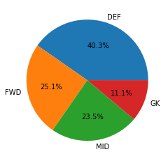

```python
#Check class distribution
%matplotlib inline

# Adapted from:
# https://www.featureranking.com/tutorials/machine-learning-tutorials/information-gain-computation/
def gini_index(y):
    probs = pd.value_counts(y,normalize=True)
    return 1 - np.sum(np.square(probs))

def plot_class_dist(y):
    class_ct = len(np.unique(y['preferred_position_cat']))
    vc = pd.value_counts(y['preferred_position_cat'])
    print('Total Records', len(y['preferred_position_cat']))
    print('Total Classes:', class_ct)
    print('Class Gini Index', gini_index(y['preferred_position_cat']))
    print('Smallest Class Id:',vc.idxmin(),'Records:',vc.min())
    print('Largest Class Id:',vc.idxmax(),'Records:',vc.max())
    print('Accuracy when Guessing:', np.round( (1 / len(np.unique(y['preferred_position_cat']))) * 100, 2), '%')

    position_counts = pd.DataFrame(y['preferred_position_cat'].value_counts())
    position_counts['Percentage'] = position_counts['preferred_position_cat']/position_counts.sum()[0]
    print(position_counts)
    plt.figure(figsize=(4,4))

    plt.pie(position_counts['Percentage'],labels = ['DEF', 'FWD', 'MID', 'GK'],  autopct='%1.1f%%');


plot_class_dist(df_players)
```

```python
# Lets create the test/train 80/20 split indexes using stratifiedshuffle split due to
# some imbalance in the classes as seen above
from sklearn.preprocessing import label_binarize
sss = StratifiedShuffleSplit(n_splits=1, test_size=0.2, random_state=45)
train_index_clf, test_index_clf = next(sss.split(X_players_clf_scaled, players_clf_y))
X_clf_train = X_players_clf_scaled[train_index_clf]
y_clf_train = players_clf_y[train_index_clf]
X_clf_test = X_players_clf_scaled[test_index_clf]
y_clf_test = players_clf_y[test_index_clf]
posn = ['DEF', 'FWD', 'GK', 'MID']
y_clf_train.shape
uniqueValues, occurCount = np.unique(y_clf_train, return_counts=True)
listOfUniqueValues = zip(uniqueValues, occurCount)
y_clf_test.shape
# Iterate over the zip object
for elem in listOfUniqueValues:
   print(elem[0] , ' Occurs : ' , (elem[1]/np.size(y_clf_train))*100, '% times')
```

```
(14620,)
```

```
(3655,)
```

```
DEF  Occurs :  40.287277701778386 % times
FWD  Occurs :  25.088919288645688 % times
GK  Occurs :  11.142270861833104 % times
MID  Occurs :  23.48153214774282 % times
```

### Task 2. Regression Stratergy

Let's take a look at current distribution of players wages in 15 bins

```python
df_players['wage_eur'].value_counts(bins=15, normalize=True)*100
```

```
(630.999, 25600.0]      91.255814
(25600.0, 50200.0]       5.619699
(50200.0, 74800.0]       1.504788
(74800.0, 99400.0]       0.689466
(99400.0, 124000.0]      0.251710
(124000.0, 148600.0]     0.218878
(148600.0, 173200.0]     0.136799
(173200.0, 197800.0]     0.103967
(197800.0, 222400.0]     0.082079
(222400.0, 247000.0]     0.049248
(247000.0, 271600.0]     0.027360
(345400.0, 370000.0]     0.016416
(296200.0, 320800.0]     0.016416
(271600.0, 296200.0]     0.016416
(320800.0, 345400.0]     0.010944
Name: wage_eur, dtype: float64
```

```python
# Lets create the test/train 80/20 split indexes using stratifiedshuffle split due to
# some imbalance in the classes as seen above
from sklearn.model_selection import train_test_split

bins = np.linspace(0, 565000.0, 15)
bins
# Save your Y values in a new ndarray,
# broken down by the bins created above.

y_binned = np.digitize(players_reg_y, bins)

# Pass y_binned to the stratify argument,
# and sklearn will handle the rest

X_reg_train, X_reg_test, y_reg_train, y_reg_test = train_test_split(X_players_reg_scaled, players_reg_y,
                                                    test_size=0.2, stratify=y_binned, random_state= 45)
```

```
array([     0.        ,  40357.14285714,  80714.28571429, 121071.42857143,
       161428.57142857, 201785.71428571, 242142.85714286, 282500.        ,
       322857.14285714, 363214.28571429, 403571.42857143, 443928.57142857,
       484285.71428571, 524642.85714286, 565000.        ])
```

We see a very imbalanced distribution we will use the train_test_split stratifying the split using 15 bins as below.

```python
print(len(X_players_reg_scaled[0]))
```

```
49
```

We can check our train data distribution now.

```python
t = pd.Series(y_reg_train)
type(t)
t.value_counts(bins=15, normalize=True)*100
```

```
pandas.core.series.Series
```

```
(630.999, 25600.0]      91.292750
(25600.0, 50200.0]       5.574555
(50200.0, 74800.0]       1.518468
(74800.0, 99400.0]       0.690834
(99400.0, 124000.0]      0.239398
(124000.0, 148600.0]     0.225718
(148600.0, 173200.0]     0.123119
(173200.0, 197800.0]     0.109439
(197800.0, 222400.0]     0.075239
(222400.0, 247000.0]     0.054720
(247000.0, 271600.0]     0.034200
(296200.0, 320800.0]     0.020520
(345400.0, 370000.0]     0.013680
(320800.0, 345400.0]     0.013680
(271600.0, 296200.0]     0.013680
dtype: float64
```

#### Create LDA features

Before considering some regression models, we create some LDA/PCA features. Here we add some additional analysis to prepare some reduced dimentionaly features.

```python
from sklearn.decomposition import PCA
from sklearn.discriminant_analysis import LinearDiscriminantAnalysis as LDA

pca = PCA(n_components=5)
X_pca = pca.fit(X_reg_train).transform(X_reg_train)

explained_variance_pca = pca.fit(X_reg_train).explained_variance_ratio_
print('-----------------------------------------------------------------')
print('PCA feature 1 explained variance ratio: ', explained_variance_pca[0])
print('PCA feature 2 explained variance ratio: ', explained_variance_pca[1])
print('PCA feature 3 explained variance ratio: ', explained_variance_pca[2])
print('PCA feature 4 explained variance ratio: ', explained_variance_pca[3])
print('PCA feature 5 explained variance ratio: ', explained_variance_pca[4])
print('-----------------------------------------------------------------')

lda = LDA(n_components=2)
X_lda_train = lda.fit(X_reg_train,y_reg_train).transform(X_reg_train)
X_lda_test = lda.fit(X_reg_test,y_reg_test).transform(X_reg_test)

explained_variance_lda = lda.fit(X_reg_train,y_reg_train).explained_variance_ratio_
print('-----------------------------------------------------------------')
print('LDA feature 1 explained variance ratio: ', explained_variance_lda[0])
print('LDA feature 2 explained variance ratio: ', explained_variance_lda[1])
print('-----------------------------------------------------------------')

#print('PCA: ', pca.components_)
#print('LDA: ', lda.scalings_.T)
```

```
-----------------------------------------------------------------
PCA feature 1 explained variance ratio:  0.3476739936045882
PCA feature 2 explained variance ratio:  0.124110241177568
PCA feature 3 explained variance ratio:  0.0806161457852826
PCA feature 4 explained variance ratio:  0.04678886825216599
PCA feature 5 explained variance ratio:  0.03424336588206113
-----------------------------------------------------------------
-----------------------------------------------------------------
LDA feature 1 explained variance ratio:  0.7075762696661373
LDA feature 2 explained variance ratio:  0.18655311338524438
-----------------------------------------------------------------
```

- First five PCA components explain 60% variance, not that impressive! We won't use PCA components for regression.
- First two LDA components explain 90% variance, very impressive! We can reduce feature numbers from 49 to 2.
- We will use the two LDA features to fit the regression models.

```
         x1        x2        y
0 -0.509942 -0.278132   7000.0
1  2.892817 -1.411154  38000.0
2 -0.586682 -0.654437   6000.0
3 -1.168647  1.535339   1000.0
4 -0.653743 -0.239578   3000.0
```

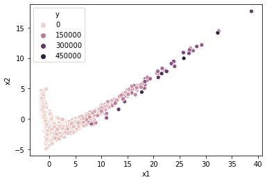

```python
df_lda = pd.DataFrame(X_lda_train)
df_lda.columns = ['x1','x2']
df_lda['y'] = y_reg_train

sns.scatterplot(data=df_lda, x="x1", y="x2", hue="y")
print(df_lda.head())

plt.show()
```

⏫ Table of Contents

# 5. Modeling and Evaluation 3

We will evaluate various models for the two task at hand.

1. Run predictive model to predict wage from players abilities. We will select some features to run regression model. Also, we will try running LDA and regression model. To measure the effectiveness, we will use RMSE, MAE and R squared.
2. Run classification model to classify players position from the players ability. To validate our models, we will use accuracy, precision, F1 score and ROC.

### Common Methods for Regression and Classification model analysis

Here we will create two methods to evaluate the classification and regression models that will use gridsearchCV (**This is also part of the exceptional work**)

We will use these dataframes to save model statistics for final comparison

```python
#We will store each model performace numCVs=10stats in this dataframe
model_clf_stats = pd.DataFrame()
model_reg_stats = pd.DataFrame()
model_reg_lda_stats = pd.DataFrame()
model_reg_yhat = pd.DataFrame()
numCVs=10
```

We will define a few common helper functions for our tasks.  
evaluate_clf_model_performance methods uses a grid searchCV scikitlearn api to evaluate a set of models that are passed to it. The best performing model is identified with the graphs show comparative statistics. The evaluation is done as follows:  
model_name: string representing the model name can be anything  
params: List of model tuning paramters  
clf: the estimator classification to evaluate  
X_train, y_train: The scaled train dataset, the grid search will use this data set and run internal CV to evaluate the model passed  
X_test, y_test: this test data set for best model estimated.  
nCV: Number of cross validation to run  
Returns :  
modal_stats: a summary of best model

```python
from sklearn.model_selection import cross_val_score
def evaluate_clf_model_performance(model_name, params, clf, X_train, y_train, X_test, y_test, nCV = 10, n_jobs =4):
    # We prepare the grid search object
    grid = gridcv(clf, params, cv=nCV,scoring='accuracy',n_jobs =-1, refit=True )
    grid.fit(X_train, y_train)
    model_stat =  pd.DataFrame()
    model_stat['model_name'] =[str(model_name)]

    res = grid.cv_results_
    #print(res)
    # Lets store the scores for t-test validation of models
    cvscore = cross_val_score(grid.best_estimator_, X_train, y_train, scoring='f1_weighted', cv=nCV,n_jobs= n_jobs)

    model_stat['scores'] = [cvscore]
    #grid.cv_results_.keys()
    res.keys()
    #res['params']
    grid_scr = pd.DataFrame()
    grid_scr['params'] = res['params']
    grid_scr['mean_test_score'] = res['mean_test_score']
    grid_scr = pd.DataFrame(grid_scr)
    #print(grid_scr)

    grid_scr.plot.bar(color='grey',figsize=(10,6))
    plt.ylabel('Accuracy')
    plt.xlabel('Params')
    plt.grid(color='blue', linestyle='--', linewidth=0.5)
    plt.ylim(0.5,.95)

    print("Best parameters set found on development set:")
    print()
    print(grid.best_params_)
    #model_stat['score'] = [grid.best_score_]
    print()
    print("Grid scores on development set:")
    print()
    means = res['mean_test_score']

    stds = res['std_test_score']
    for mean, std, params in zip(means, stds, res['params']):
        print("%0.5f (+/-%0.03f) for %r"
              % (mean, std * 2, params))
    print()

    print("Detailed classification report:")
    print()
    print("The model is trained on the full development set.")
    print("The scores are computed on the full evaluation set.")
    print()
    #build CM using test/Train
    y_true, y_pred = y_test, grid.predict(X_test)
    #y_pred
    print(classification_report(y_true, y_pred, target_names=['DEF', 'FWD', 'GK','MID']))
    s = classification_report(y_true, y_pred, target_names=['DEF', 'FWD', 'GK','MID'])
    model_stat['CM'] = s
    plot_confusion_matrix(grid, X_test,y_test,cmap=plt.cm.Blues,values_format='d')
    model_stat['time_refit'] = [grid.refit_time_]
    model_stat['model_param'] = [str(grid.best_params_)]
    model_stat['weighted_f1_score']=round(f1_score(y_true, y_pred, average='weighted'),2)
    #model_stat['accuracy']=accuracy_score(y_true, y_pred)
    plt.grid(b=None);
    print()
    return model_stat
```

#### Custom Scorers for Evaluating Regression Models

**All regression models created in this notebook are validated using the following metrics:**

- Mean Absolute Error (MAE)
- Root Mean Squared Error (RMSE) - https://stackoverflow.com/questions/17197492/root-mean-square-error-in-python
- Mean Absolute Percentage Error (MAPE) - https://stackoverflow.com/questions/42250958/how-to-optimize-mape-code-in-python
- R^2 (R2) - https://stackoverflow.com/questions/59315992/cross-validation-in-r-vs-scikit-learn-for-linear-regression-r2

Helper method

```python
#Use mean absolute error (MAE) to score the regression models created
#(the scale of MAE is identical to the response variable)
from sklearn.metrics import mean_absolute_error, make_scorer, mean_squared_error, r2_score

#Function for Root mean squared error
#https://stackoverflow.com/questions/17197492/root-mean-square-error-in-python
def rmse(y_actual, y_predicted):
    return np.sqrt(mean_squared_error(y_actual, y_predicted))

#Function for Mean Absolute Percentage Error (MAPE) - Untested
#Adapted from - https://stackoverflow.com/questions/42250958/how-to-optimize-mape-code-in-python
def mape(y_actual, y_predicted):
    mask = y_actual != 0
    return (np.fabs(y_actual - y_predicted)/y_actual)[mask].mean() * 100

#Create scorers for rmse and mape functions
mae_scorer = make_scorer(score_func=mean_absolute_error, greater_is_better=False)
rmse_scorer = make_scorer(score_func=rmse, greater_is_better=False)
mape_scorer = make_scorer(score_func=mape, greater_is_better=False)
r2_scorer = make_scorer(score_func=r2_score, greater_is_better=True)

#Make scorer array to pass into cross_validate() function for producing mutiple scores for each cv fold.
errorScoring = {'MAE':  mae_scorer,
                'RMSE': rmse_scorer,
                'MAPE': mape_scorer,
                'R2': r2_scorer,
                }
```

Helper method

```python
from sklearn.model_selection import cross_validate
import seaborn as sns
# colors = ["windows blue", "amber", "greyish", "faded green", "dusty purple"]
# pal = sns.xkcd_palette(colors)
import pprint

def EvaluateRegressionEstimator(regEstimator, X, y, cv):

    scores = cross_validate(regEstimator, X, y, scoring=errorScoring, cv=cv, return_train_score=True)
    #print('scores = \n')
    #pp = pprint.PrettyPrinter(indent=1)
    #pp.pprint(scores)

    #cross val score sign-flips the outputs of MAE
    # https://github.com/scikit-learn/scikit-learn/issues/2439
    scores['test_MAE'] = scores['test_MAE'] * -1
    scores['test_MAPE'] = scores['test_MAPE'] * -1
    scores['test_RMSE'] = scores['test_RMSE'] * -1

    #print mean MAE for all folds
    maeAvg = scores['test_MAE'].mean()
    print_str = "The average MAE for all cv folds is: \t\t\t {maeAvg:.5}"
    print(print_str.format(maeAvg=maeAvg))

    #print mean test_MAPE for all folds
    scores['test_MAPE'] = scores['test_MAPE']
    mape_avg = scores['test_MAPE'].mean()
    print_str = "The average MAE percentage (MAPE) for all cv folds is: \t {mape_avg:.5}"
    print(print_str.format(mape_avg=mape_avg))

    #print mean MAE for all folds
    RMSEavg = scores['test_RMSE'].mean()
    print_str = "The average RMSE for all cv folds is: \t\t\t {RMSEavg:.5}"
    print(print_str.format(RMSEavg=RMSEavg))

    #print mean R2 for all folds
    R2avg = scores['test_R2'].mean()
    print_str = "The average R2 for all cv folds is: \t\t\t {R2avg:.5}"
    print(print_str.format(R2avg=R2avg))
    print('*********************************************************')

    print('Cross Validation Fold Mean Error Scores')
    scoresResults = pd.DataFrame()
    scoresResults['MAE'] = scores['test_MAE']
    scoresResults['MAPE'] = scores['test_MAPE']
    scoresResults['RMSE'] = scores['test_RMSE']
    scoresResults['R2'] = scores['test_R2']
    print(scoresResults)
    return scoresResults

def plot_kde_y_yhat(y, y_):
    plot_df = pd.DataFrame()
    plot_df['y'] = y
    plot_df['yhat'] = y_

    # Change negative yhat to 0 as wage can't be negative value
    plot_df[plot_df['yhat']<0] = 0
    ax1 = sns.distplot(plot_df['y'], kde=True, color='#4472C4', hist=False, label='Actual wages')
    sns.distplot(plot_df['yhat'], kde=True, color='#FF9900', hist=False, label='Predicted wages', ax=ax1)
    ax1.set(xlim=(-10000,150000))
    ax1.set_title("Actual wages vs. Predicted wages")
    plt.xlabel('Wages (€)')
    plt.ylabel('Gaussian Kernel Density Estimate')
```

evaluate_reg_model_performance methods uses a grid searchCV scikitlearn api to evaluate a set of models that are passed to it. The best performing model is identified with the graphs show comparative statistics. The evaluation is done as follows:  
model_name: string representing the model name can be anything  
params: List of model tuning paramters clf: the estimator classification to evaluate  
X_train, y_train: The scaled train dataset, the grid search will use this data set and run internal CV to evaluate the model passed  
X_test, y_test: this test data set for best model estimated.  
nCV: Number of cross validation to run

Returns : modal_stats: a summary of best model

```python
from sklearn.metrics import make_scorer
from sklearn.metrics import mean_squared_error
from sklearn.metrics import mean_absolute_error
from sklearn.metrics import r2_score
import pprint
from yellowbrick.regressor import ResidualsPlot
from yellowbrick.regressor import PredictionError
from yellowbrick.regressor import CooksDistance
plt.style.use('seaborn')
%matplotlib inline

def evaluate_reg_model_performance(model_name,params,clf,score,X_train,y_train,X_test,y_test,nCV=10,n_jobs=-1):
    # We prepare the grid search object
    # and custom scorer
    mape_scorer = make_scorer(score_func=mape, greater_is_better=False)
    scoring = {'RMSE': 'neg_root_mean_squared_error',
               'MAE': 'neg_mean_absolute_error',
               'MAPE': mape_scorer,
               'R2': 'r2'}

    grid = gridcv(clf, params, cv=nCV, scoring=scoring, n_jobs=n_jobs, refit=score, return_train_score=True)
    grid.fit(X_train, y_train)
    model_stat = pd.DataFrame()
    model_stat['model_name'] = [str(model_name)]
    print("Best parameters set found:")
    print(grid.best_params_)
    res = grid.cv_results_
    #pp = pprint.PrettyPrinter(indent=1)
    #pp.pprint(res)

    grid_scr = pd.DataFrame()
    grid_scr['params'] = res['params']
    grid_scr['RMSE'] = -res['mean_test_RMSE']
    grid_scr['MAPE'] = -res['mean_test_MAPE']
    grid_scr['MAE'] = -res['mean_test_MAE']
    grid_scr['R2'] = res['mean_test_R2']
    grid_scr = pd.DataFrame(grid_scr)
    print('\nMean score summary of each gridsearch estimator executed')
    #display(Markdown(grid_scr.to_markdown()))

    x = np.arange(len(grid_scr['params'])).astype(int)

    plt.subplots(2, 2, figsize=(12, 6))

    plt.subplot(221)
    plt.bar(x, grid_scr['RMSE'])
    plt.ylabel('RMSE')
    #plt.xlabel('Parameter')
    plt.title('RMSE mean scores (nCV=%i)'%nCV)
    plt.grid(color='grey', linestyle='--', linewidth=0.3)

    plt.subplot(222)
    plt.bar(x, grid_scr['MAPE'])
    plt.ylabel('MAPE')
    #plt.xlabel('Parameter')
    plt.title('MAPE mean scores (nCV=%i)'%nCV)
    plt.grid(color='grey', linestyle='--', linewidth=0.3)

    plt.subplot(223)
    plt.bar(x, grid_scr['MAE'])
    plt.ylabel('MAE')
    plt.xlabel('Parameter')
    plt.title('MAE mean scores (nCV=%i)'%nCV)
    plt.grid(color='grey', linestyle='--', linewidth=0.3)

    plt.subplot(224)
    plt.bar(x, grid_scr['R2'])
    plt.ylabel('R2')
    plt.xlabel('Parameter')
    plt.title('R2 mean scores (nCV=%i)'%nCV)
    plt.grid(color='grey', linestyle='--', linewidth=0.3)

    plt.subplots_adjust(left=0.125, right=0.8, wspace=0.3, hspace=0.4)
    plt.show()

    print(nCV, 'fold cross validation average scores of the best Estimator found by GridSearchCV\n')
    e = EvaluateRegressionEstimator(grid.best_estimator_, X_train, y_train, nCV)
    model_stat['model_name']
    model_stat['RMSE'] = grid_scr['RMSE']
    model_stat['MAPE'] = grid_scr['MAPE']
    model_stat['MAE'] = grid_scr['MAE']
    model_stat['R2'] = grid_scr['R2']
    #display(Markdown(e.to_markdown()))
    #prediction

    if model_name in ['Linear Reg', 'Lasso Reg', 'Ridge Reg', 'Linear Reg_LDA', 'Lasso Reg_LDA', 'Ridge Reg_LDA']:
        plt.subplots(1, 2, figsize=(12, 4))
        plt.subplot(121)
        grid.fit(X_train, y_train)
        yhat = grid.predict(X_test)
        plot_kde_y_yhat(y_test, yhat)

        plt.subplot(122)
        visualizer = ResidualsPlot(clf)
        visualizer.fit(X_train, y_train)
        visualizer.score(X_test, y_test)
        visualizer.show()
        plt.show()

        plt.subplots(1, 2, figsize=(13,4))
        plt.subplot(121)
        visualizer = PredictionError(clf)
        visualizer.fit(X_train, y_train)
        visualizer.score(X_test, y_test)
        visualizer.finalize()

        plt.subplot(122)
        visualizer = CooksDistance()
        visualizer.fit(X_test, y_test)
        visualizer.finalize()
        plt.show()
    else:
        grid.fit(X_train, y_train)
        yhat = grid.predict(X_test)
        plot_kde_y_yhat(y_test, yhat)

    yhat_df = pd.DataFrame(yhat)
    yhat_df = yhat_df.rename({0: model_name}, axis='columns')

    return (model_stat, yhat_df)
```

### Task 1. Classification model Evaluation

#### Classification Models:

1. KNN
2. Naive Bayes
3. Random Forests
4. AdaBoost
5. Decision Trees
6. Extra Trees
7. XGBoost
8. Support Vector Machines (Original Data)
9. Support Vector Machines (SMOTE sampling)

#### 1. KNN

```
Best parameters set found on development set:

{'algorithm': 'auto', 'n_neighbors': 97}

Grid scores on development set:

0.81361 (+/-0.017) for {'algorithm': 'auto', 'n_neighbors': 3}
0.82456 (+/-0.012) for {'algorithm': 'auto', 'n_neighbors': 5}
0.84022 (+/-0.016) for {'algorithm': 'auto', 'n_neighbors': 45}
0.84029 (+/-0.015) for {'algorithm': 'auto', 'n_neighbors': 47}
0.84077 (+/-0.014) for {'algorithm': 'auto', 'n_neighbors': 49}
0.84118 (+/-0.013) for {'algorithm': 'auto', 'n_neighbors': 65}
0.84166 (+/-0.012) for {'algorithm': 'auto', 'n_neighbors': 97}
0.83789 (+/-0.015) for {'algorithm': 'auto', 'n_neighbors': 151}
0.83502 (+/-0.015) for {'algorithm': 'auto', 'n_neighbors': 251}

Detailed classification report:

The model is trained on the full development set.
The scores are computed on the full evaluation set.

              precision    recall  f1-score   support

         DEF       0.90      0.95      0.92      1472
         FWD       0.82      0.78      0.80       917
          GK       1.00      1.00      1.00       407
         MID       0.67      0.65      0.66       859

    accuracy                           0.84      3655
   macro avg       0.85      0.84      0.85      3655
weighted avg       0.84      0.84      0.84      3655


Wall time: 38.7 s
```

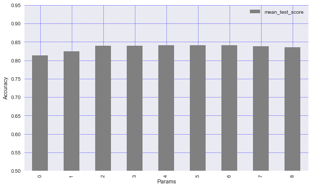

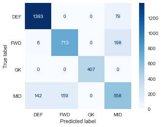

```python
from sklearn.neighbors import KNeighborsClassifier
params = [{
          'n_neighbors' : [3, 5, 45, 47, 49, 65, 97, 151, 251],
          'algorithm'  :  ['auto']
         }]
KNN = KNeighborsClassifier()
%time m = evaluate_clf_model_performance('KNN', params,KNN,X_clf_train, y_clf_train, X_clf_test, y_clf_test, numCVs)
model_clf_stats = model_clf_stats.append(m)
```

#### 2. Naive Bayes

```
Best parameters set found on development set:

{'priors': None, 'var_smoothing': 1e-05}

Grid scores on development set:

0.78105 (+/-0.014) for {'priors': None, 'var_smoothing': 1e-09}
0.78112 (+/-0.014) for {'priors': None, 'var_smoothing': 1e-05}
0.78105 (+/-0.014) for {'priors': None, 'var_smoothing': 0.001}
0.77722 (+/-0.012) for {'priors': None, 'var_smoothing': 0.1}
0.77175 (+/-0.013) for {'priors': None, 'var_smoothing': 1}

Detailed classification report:

The model is trained on the full development set.
The scores are computed on the full evaluation set.

              precision    recall  f1-score   support

         DEF       0.93      0.82      0.87      1472
         FWD       0.78      0.76      0.77       917
          GK       1.00      1.00      1.00       407
         MID       0.54      0.67      0.60       859

    accuracy                           0.79      3655
   macro avg       0.81      0.81      0.81      3655
weighted avg       0.81      0.79      0.80      3655


Wall time: 3.57 s
```

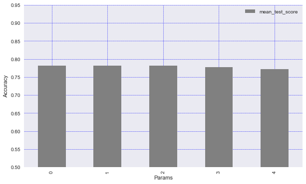

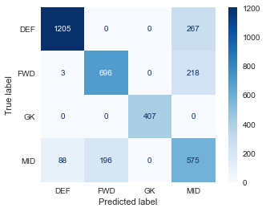

```python
from sklearn.naive_bayes import GaussianNB
params = [{
         'priors': [None],
          'var_smoothing': [1e-09,1e-05, 1e-03, 1e-01, 1]
         }]
GNB = GaussianNB()
%time m = evaluate_clf_model_performance('GNB', params,GNB,X_clf_train, y_clf_train, X_clf_test, y_clf_test, numCVs)
model_clf_stats = model_clf_stats.append(m)
```

#### 3. Random Forests

```
Best parameters set found on development set:

{'criterion': 'entropy', 'max_features': 'auto', 'min_samples_leaf': 5, 'n_estimators': 100, 'random_state': 0}

Grid scores on development set:

0.85602 (+/-0.015) for {'criterion': 'gini', 'max_features': 'auto', 'min_samples_leaf': 5, 'n_estimators': 50, 'random_state': 0}
0.85807 (+/-0.014) for {'criterion': 'gini', 'max_features': 'auto', 'min_samples_leaf': 5, 'n_estimators': 100, 'random_state': 0}
0.85725 (+/-0.015) for {'criterion': 'gini', 'max_features': 'auto', 'min_samples_leaf': 5, 'n_estimators': 150, 'random_state': 0}
0.85513 (+/-0.015) for {'criterion': 'gini', 'max_features': 'auto', 'min_samples_leaf': 10, 'n_estimators': 50, 'random_state': 0}
0.85663 (+/-0.015) for {'criterion': 'gini', 'max_features': 'auto', 'min_samples_leaf': 10, 'n_estimators': 100, 'random_state': 0}
0.85636 (+/-0.015) for {'criterion': 'gini', 'max_features': 'auto', 'min_samples_leaf': 10, 'n_estimators': 150, 'random_state': 0}
0.85602 (+/-0.015) for {'criterion': 'gini', 'max_features': 'sqrt', 'min_samples_leaf': 5, 'n_estimators': 50, 'random_state': 0}
0.85807 (+/-0.014) for {'criterion': 'gini', 'max_features': 'sqrt', 'min_samples_leaf': 5, 'n_estimators': 100, 'random_state': 0}
0.85725 (+/-0.015) for {'criterion': 'gini', 'max_features': 'sqrt', 'min_samples_leaf': 5, 'n_estimators': 150, 'random_state': 0}
0.85513 (+/-0.015) for {'criterion': 'gini', 'max_features': 'sqrt', 'min_samples_leaf': 10, 'n_estimators': 50, 'random_state': 0}
0.85663 (+/-0.015) for {'criterion': 'gini', 'max_features': 'sqrt', 'min_samples_leaf': 10, 'n_estimators': 100, 'random_state': 0}
0.85636 (+/-0.015) for {'criterion': 'gini', 'max_features': 'sqrt', 'min_samples_leaf': 10, 'n_estimators': 150, 'random_state': 0}
0.85575 (+/-0.021) for {'criterion': 'entropy', 'max_features': 'auto', 'min_samples_leaf': 5, 'n_estimators': 50, 'random_state': 0}
0.85848 (+/-0.017) for {'criterion': 'entropy', 'max_features': 'auto', 'min_samples_leaf': 5, 'n_estimators': 100, 'random_state': 0}
0.85759 (+/-0.016) for {'criterion': 'entropy', 'max_features': 'auto', 'min_samples_leaf': 5, 'n_estimators': 150, 'random_state': 0}
0.85602 (+/-0.017) for {'criterion': 'entropy', 'max_features': 'auto', 'min_samples_leaf': 10, 'n_estimators': 50, 'random_state': 0}
0.85554 (+/-0.017) for {'criterion': 'entropy', 'max_features': 'auto', 'min_samples_leaf': 10, 'n_estimators': 100, 'random_state': 0}
0.85636 (+/-0.015) for {'criterion': 'entropy', 'max_features': 'auto', 'min_samples_leaf': 10, 'n_estimators': 150, 'random_state': 0}
0.85575 (+/-0.021) for {'criterion': 'entropy', 'max_features': 'sqrt', 'min_samples_leaf': 5, 'n_estimators': 50, 'random_state': 0}
0.85848 (+/-0.017) for {'criterion': 'entropy', 'max_features': 'sqrt', 'min_samples_leaf': 5, 'n_estimators': 100, 'random_state': 0}
0.85759 (+/-0.016) for {'criterion': 'entropy', 'max_features': 'sqrt', 'min_samples_leaf': 5, 'n_estimators': 150, 'random_state': 0}
0.85602 (+/-0.017) for {'criterion': 'entropy', 'max_features': 'sqrt', 'min_samples_leaf': 10, 'n_estimators': 50, 'random_state': 0}
0.85554 (+/-0.017) for {'criterion': 'entropy', 'max_features': 'sqrt', 'min_samples_leaf': 10, 'n_estimators': 100, 'random_state': 0}
0.85636 (+/-0.015) for {'criterion': 'entropy', 'max_features': 'sqrt', 'min_samples_leaf': 10, 'n_estimators': 150, 'random_state': 0}

Detailed classification report:

The model is trained on the full development set.
The scores are computed on the full evaluation set.

              precision    recall  f1-score   support

         DEF       0.92      0.96      0.94      1472
         FWD       0.82      0.82      0.82       917
          GK       1.00      1.00      1.00       407
         MID       0.72      0.66      0.69       859

    accuracy                           0.86      3655
   macro avg       0.86      0.86      0.86      3655
weighted avg       0.86      0.86      0.86      3655


Wall time: 1min 35s
```

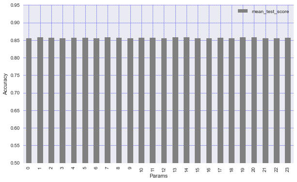

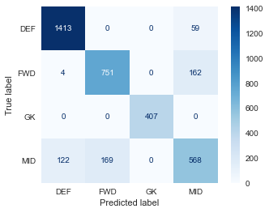

```python
from sklearn.ensemble import RandomForestClassifier
n_estimators = range(50, 200, 50)
params = [{
    'n_estimators' : n_estimators,
    'criterion': ['gini', 'entropy'],
    'min_samples_leaf': [5,10],
    'max_features': ['auto', 'sqrt'],
    'random_state': [0]}]
RF = RandomForestClassifier()
%time m = evaluate_clf_model_performance('RF', params,RF,X_clf_train, y_clf_train, X_clf_test, y_clf_test, numCVs)
model_clf_stats = model_clf_stats.append(m)
```

#### 4. AdaBoost

```
Best parameters set found on development set:

{'algorithm': 'SAMME', 'n_estimators': 150, 'random_state': 0}

Grid scores on development set:

0.80609 (+/-0.016) for {'algorithm': 'SAMME', 'n_estimators': 50, 'random_state': 0}
0.81457 (+/-0.016) for {'algorithm': 'SAMME', 'n_estimators': 100, 'random_state': 0}
0.81566 (+/-0.016) for {'algorithm': 'SAMME', 'n_estimators': 150, 'random_state': 0}
0.71573 (+/-0.047) for {'algorithm': 'SAMME.R', 'n_estimators': 50, 'random_state': 0}
0.71566 (+/-0.047) for {'algorithm': 'SAMME.R', 'n_estimators': 100, 'random_state': 0}
0.71573 (+/-0.047) for {'algorithm': 'SAMME.R', 'n_estimators': 150, 'random_state': 0}

Detailed classification report:

The model is trained on the full development set.
The scores are computed on the full evaluation set.

              precision    recall  f1-score   support

         DEF       0.91      0.95      0.93      1472
         FWD       0.70      0.91      0.79       917
          GK       1.00      1.00      1.00       407
         MID       0.72      0.43      0.54       859

    accuracy                           0.83      3655
   macro avg       0.83      0.82      0.82      3655
weighted avg       0.82      0.83      0.81      3655


Wall time: 59.5 s
```

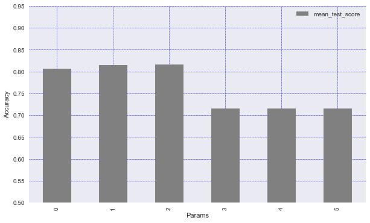

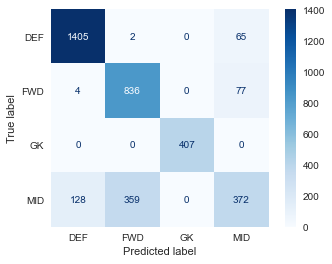

```python
from sklearn.ensemble import AdaBoostClassifier
n_estimators = range(50, 200, 50)
params = [{
          'n_estimators' : n_estimators,
           'algorithm': ['SAMME', 'SAMME.R'],
           'random_state': [0]
         }]
Ada = AdaBoostClassifier()
%time m = evaluate_clf_model_performance('AdaBoost', params,Ada,X_clf_train, y_clf_train, X_clf_test, y_clf_test, numCVs)
model_clf_stats = model_clf_stats.append(m)
```

#### 5. Decision Trees

```
Best parameters set found on development set:

{'criterion': 'gini', 'min_samples_leaf': 10, 'random_state': 0, 'splitter': 'random'}

Grid scores on development set:

0.80759 (+/-0.024) for {'criterion': 'gini', 'min_samples_leaf': 5, 'random_state': 0, 'splitter': 'best'}
0.80985 (+/-0.021) for {'criterion': 'gini', 'min_samples_leaf': 5, 'random_state': 0, 'splitter': 'random'}
0.80800 (+/-0.018) for {'criterion': 'gini', 'min_samples_leaf': 10, 'random_state': 0, 'splitter': 'best'}
0.81628 (+/-0.018) for {'criterion': 'gini', 'min_samples_leaf': 10, 'random_state': 0, 'splitter': 'random'}
0.80041 (+/-0.021) for {'criterion': 'entropy', 'min_samples_leaf': 5, 'random_state': 0, 'splitter': 'best'}
0.79911 (+/-0.030) for {'criterion': 'entropy', 'min_samples_leaf': 5, 'random_state': 0, 'splitter': 'random'}
0.80739 (+/-0.019) for {'criterion': 'entropy', 'min_samples_leaf': 10, 'random_state': 0, 'splitter': 'best'}
0.81149 (+/-0.019) for {'criterion': 'entropy', 'min_samples_leaf': 10, 'random_state': 0, 'splitter': 'random'}

Detailed classification report:

The model is trained on the full development set.
The scores are computed on the full evaluation set.

              precision    recall  f1-score   support

         DEF       0.90      0.93      0.91      1472
         FWD       0.77      0.78      0.77       917
          GK       1.00      0.99      0.99       407
         MID       0.62      0.59      0.60       859

    accuracy                           0.82      3655
   macro avg       0.82      0.82      0.82      3655
weighted avg       0.81      0.82      0.81      3655


Wall time: 5.43 s
```

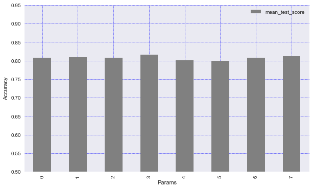

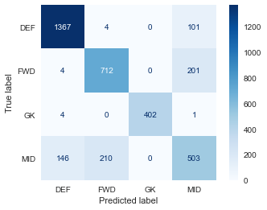

```python
from sklearn.tree import DecisionTreeClassifier
params = [{
    'splitter': ['best', 'random'],
    'criterion' : ['gini','entropy'],
    'min_samples_leaf': [5,10],
    'random_state': [0]
         }]
Decisiontree = DecisionTreeClassifier()
%time m = evaluate_clf_model_performance('Decisiontree', params,Decisiontree,X_clf_train, y_clf_train, X_clf_test, y_clf_test, numCVs)
model_clf_stats = model_clf_stats.append(m)
```

```
Best parameters set found on development set:

{'criterion': 'gini', 'max_features': 'auto', 'min_samples_leaf': 10, 'random_state': 0}

Grid scores on development set:

0.80109 (+/-0.011) for {'criterion': 'gini', 'max_features': 'auto', 'min_samples_leaf': 5, 'random_state': 0}
0.80780 (+/-0.019) for {'criterion': 'gini', 'max_features': 'auto', 'min_samples_leaf': 10, 'random_state': 0}
0.80109 (+/-0.011) for {'criterion': 'gini', 'max_features': 'sqrt', 'min_samples_leaf': 5, 'random_state': 0}
0.80780 (+/-0.019) for {'criterion': 'gini', 'max_features': 'sqrt', 'min_samples_leaf': 10, 'random_state': 0}
0.80410 (+/-0.023) for {'criterion': 'entropy', 'max_features': 'auto', 'min_samples_leaf': 5, 'random_state': 0}
0.80171 (+/-0.022) for {'criterion': 'entropy', 'max_features': 'auto', 'min_samples_leaf': 10, 'random_state': 0}
0.80410 (+/-0.023) for {'criterion': 'entropy', 'max_features': 'sqrt', 'min_samples_leaf': 5, 'random_state': 0}
0.80171 (+/-0.022) for {'criterion': 'entropy', 'max_features': 'sqrt', 'min_samples_leaf': 10, 'random_state': 0}

Detailed classification report:

The model is trained on the full development set.
The scores are computed on the full evaluation set.

              precision    recall  f1-score   support

         DEF       0.90      0.91      0.91      1472
         FWD       0.76      0.77      0.76       917
          GK       1.00      1.00      1.00       407
         MID       0.60      0.58      0.59       859

    accuracy                           0.81      3655
   macro avg       0.81      0.81      0.81      3655
weighted avg       0.81      0.81      0.81      3655


Wall time: 4.54 s
```

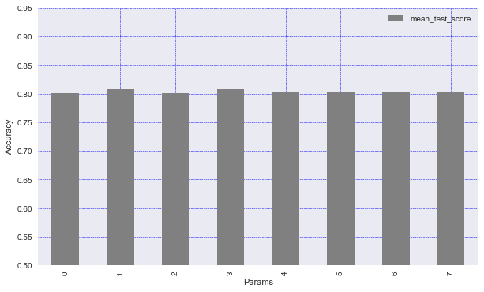

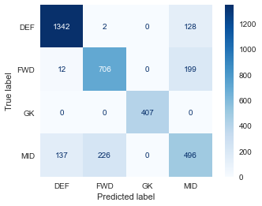

```python
from sklearn.tree import ExtraTreeClassifier
params = [{
    'criterion' : ['gini', 'entropy'],
    'min_samples_leaf': [5,10],
    'max_features': ['auto', 'sqrt'],
    'random_state': [0]
         }]
Extratree = ExtraTreeClassifier()
%time m = evaluate_clf_model_performance('Extratree', params,Decisiontree,X_clf_train, y_clf_train, X_clf_test, y_clf_test, numCVs)
model_clf_stats = model_clf_stats.append(m)
```

#### 7. XGBoost

```
Best parameters set found on development set:

{'booster': 'gbtree', 'n_estimators': 50, 'random_state': 0}

Grid scores on development set:

0.85643 (+/-0.014) for {'booster': 'gbtree', 'n_estimators': 50, 'random_state': 0}
0.85609 (+/-0.020) for {'booster': 'gbtree', 'n_estimators': 100, 'random_state': 0}
0.85568 (+/-0.020) for {'booster': 'gbtree', 'n_estimators': 150, 'random_state': 0}
0.85465 (+/-0.018) for {'booster': 'gbtree', 'n_estimators': 200, 'random_state': 0}
0.85014 (+/-0.013) for {'booster': 'gblinear', 'n_estimators': 50, 'random_state': 0}
0.85164 (+/-0.014) for {'booster': 'gblinear', 'n_estimators': 100, 'random_state': 0}
0.85171 (+/-0.012) for {'booster': 'gblinear', 'n_estimators': 150, 'random_state': 0}
0.85164 (+/-0.011) for {'booster': 'gblinear', 'n_estimators': 200, 'random_state': 0}

Detailed classification report:

The model is trained on the full development set.
The scores are computed on the full evaluation set.

              precision    recall  f1-score   support

         DEF       0.93      0.95      0.94      1472
         FWD       0.81      0.81      0.81       917
          GK       1.00      1.00      1.00       407
         MID       0.71      0.68      0.69       859

    accuracy                           0.86      3655
   macro avg       0.86      0.86      0.86      3655
weighted avg       0.86      0.86      0.86      3655


Wall time: 2min
```

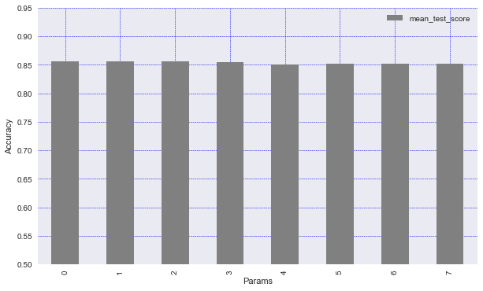

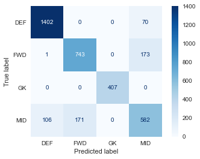

```python
from xgboost import XGBClassifier
n_estimators = range(50, 250, 50)
params = [{
    'n_estimators' : n_estimators,
    'booster': ['gbtree','gblinear'],
    'random_state': [0]
         }]
XGBClassifier = XGBClassifier()
%time m = evaluate_clf_model_performance('XGBClassifier', params,XGBClassifier,X_clf_train, y_clf_train, X_clf_test, y_clf_test, numCVs)
model_clf_stats = model_clf_stats.append(m)
```

#### 8. Support Vector Machines (Original Data)

Another supervised learning model that is used in this minilab is the support vector machine (SVM) and can be considered an extension of the perceptron. We will now perform multiclass support vector analysis using various tuning perameters. SVM is a powerful machine learning technique which is capable of performing both linear, nonlinear classifications, regression and outlier detection. SVM's are good for small and medium size datsets.

```
Best parameters set found on development set:

{'C': 75, 'gamma': 0.01, 'kernel': 'rbf'}

Grid scores on development set:

0.85992 (+/-0.019) for {'C': 100, 'gamma': 0.01, 'kernel': 'rbf'}
0.83167 (+/-0.019) for {'C': 100, 'gamma': 0.05, 'kernel': 'rbf'}
0.86094 (+/-0.019) for {'C': 75, 'gamma': 0.01, 'kernel': 'rbf'}
0.83372 (+/-0.020) for {'C': 75, 'gamma': 0.05, 'kernel': 'rbf'}

Detailed classification report:

The model is trained on the full development set.
The scores are computed on the full evaluation set.

              precision    recall  f1-score   support

         DEF       0.94      0.95      0.94      1472
         FWD       0.83      0.82      0.83       917
          GK       1.00      1.00      1.00       407
         MID       0.72      0.71      0.72       859

    accuracy                           0.87      3655
   macro avg       0.87      0.87      0.87      3655
weighted avg       0.87      0.87      0.87      3655


Wall time: 1min 10s
```

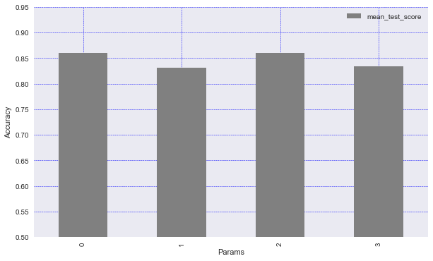

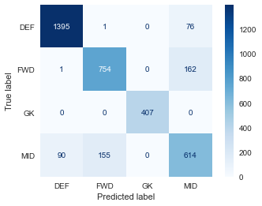

```python
#SVC 1
from sklearn.svm import SVC
params = [
      {'C': [100,75], 'gamma': [.01,.05], 'kernel': ['rbf']},
     ]
SVC = SVC()
%time m = evaluate_clf_model_performance('SVC', params,SVC,X_clf_train, y_clf_train, X_clf_test, y_clf_test, numCVs)
model_clf_stats = model_clf_stats.append(m)
```

#### 9. Support Vector Machines (SMOTE sampling)

SMOTE (Synthetic Minority Over-sampling) works by selecting examples that are close in the feature space, drawing a line between the examples in the feature space and drawing a new sample at a point along that line. Specifically, a random example from the minority class is first chosen. Then k of the nearest neighbors for that example are found (typically k=5). A randomly selected neighbor is chosen and a synthetic example is created at a randomly selected point between the two examples in feature space.  
şş https://machinelearningmastery.com/smote-oversampling-for-imbalanced-classification/

Since SMOTE sampling performed real good in LR we will try this sampling stratergy using SVC. We reduced parameters and cv for model testing in the final paper as the SMOTE SVC takes a lot of procesing time.

```python
# Plot the new class distributions for y using the same funnction as above.
def plot_class_dist_1(players_y):
    fig, axarr = plt.subplots(1, 2, figsize=(18, 6))
    class_ct = len(np.unique(players_y))
    vc = pd.value_counts(players_y)
    print('Total Records', len(players_y))
    print('Total Classes:', class_ct)
    print('Class Gini Index', gini_index(players_y))
    print('Smallest Class Id:',vc.idxmin(),'Records:',vc.min())
    print('Largest Class Id:',vc.idxmax(),'Records:',vc.max())
    print('Accuracy when Guessing:', np.round( (1 / len(np.unique(players_y))) * 100, 2), '%')

    sns.distplot(players_y, ax=axarr[0], bins=class_ct).set_title('Minilab Class Distribution');
    sns.distplot(players_y, ax=axarr[1], kde=False, bins=class_ct).set_title('Minilab Class Counts');
```

```
Total Records 29448
Total Classes: 4
Class Gini Index 0.75
Smallest Class Id: [2] Records: 7362
Largest Class Id: [2] Records: 7362
Accuracy when Guessing: 25.0 %
```

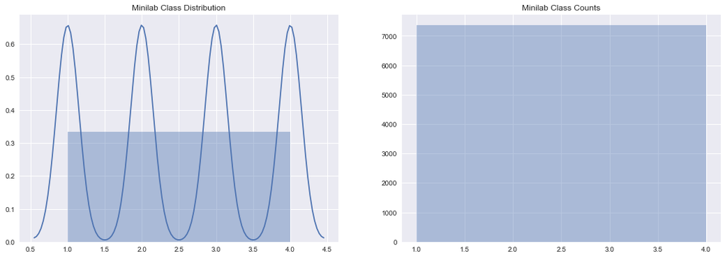

```python
from imblearn.over_sampling import SMOTE

# Oversample using SMOTE
# Make all classes the same size as the majority class.
# WARNING - This can exponentially increase the size of the input dataset.
sm = SMOTE(sampling_strategy='not majority')
X_clf_sm, y_clf_sm = sm.fit_sample(X_players_clf_scaled, players_clf_y)

y_clf_sm_new = y_clf_sm.copy()
y_clf_sm_new = pd.DataFrame(y_clf_sm_new)
y_clf_sm_new.columns = ['label']

dicta = {'DEF':1, 'FWD':2, 'MID':3, 'GK':4}
y_clf_sm_new['label'] = y_clf_sm_new['label'].map(dicta)
y_clf_sm_new1 = y_clf_sm_new.values.tolist()

plot_class_dist_1(y_clf_sm_new1)
```

```python
cv_object = StratifiedShuffleSplit(n_splits=1, test_size=0.2, random_state=0)
train_index_us, test_index_us = next(cv_object.split(X_clf_sm, y_clf_sm))
X_clf_sm_train = X_clf_sm[train_index_us]
y_clf_sm_train = y_clf_sm[train_index_us]
X_clf_sm_test = X_clf_sm[test_index_us]
y_clf_sm_test = y_clf_sm[test_index_us]
```

```
Best parameters set found on development set:

{'C': 100, 'class_weight': None, 'gamma': 0.1, 'kernel': 'rbf'}

Grid scores on development set:

0.91519 (+/-0.008) for {'C': 100, 'class_weight': None, 'gamma': 0.1, 'kernel': 'rbf'}
0.90933 (+/-0.005) for {'C': 100, 'class_weight': None, 'gamma': 0.05, 'kernel': 'rbf'}

Detailed classification report:

The model is trained on the full development set.
The scores are computed on the full evaluation set.

              precision    recall  f1-score   support

         DEF       0.94      0.92      0.93      1473
         FWD       0.91      0.91      0.91      1473
          GK       1.00      1.00      1.00      1472
         MID       0.84      0.86      0.85      1472

    accuracy                           0.92      5890
   macro avg       0.92      0.92      0.92      5890
weighted avg       0.92      0.92      0.92      5890


Wall time: 1min
```

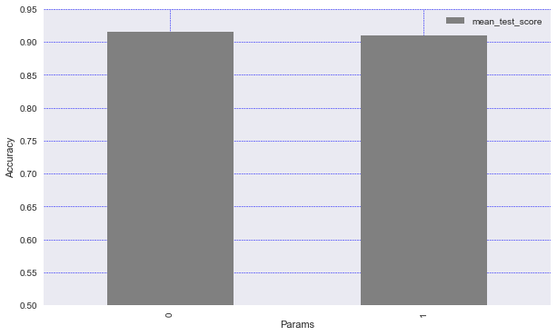

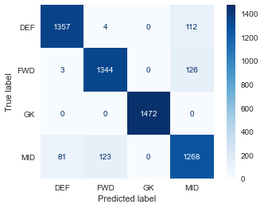

```python
#SVC SMOTE
from sklearn.svm import SVC
params = [
      {'C': [100], 'class_weight': [None],'gamma': [.1,.05], 'kernel': ['rbf']},
     ]
SVC = SVC()
%time m = evaluate_clf_model_performance('SVC SMOTE', params,SVC,X_clf_sm_train, y_clf_sm_train, X_clf_sm_test, y_clf_sm_test,5)
model_clf_stats = model_clf_stats.append(m)
```

### Task 2. Regression model Evaluation

Now we will consider the following regression models.

### Regression Models: (with original scaled features)

1. Linear Regression
2. Lasso Regression
3. Ridge Regression
4. Elastic Net Regression
5. Random Forest Regression
6. Extra Trees Regression
7. Multilayer Perceptron Regression
8. Support Vector Regression

### Regression Models: (with 2 LDA features)

1. Linear Regression
2. Lasso Regression
3. Ridge Regression
4. Elastic Net Regression
5. Random Forest Regression
6. Extra Trees Regression
7. Multilayer Perceptron Regression
8. Support Vector Regression

### 1. Linear Regression

```
Best parameters set found:
{'fit_intercept': True, 'normalize': True}

Mean score summary of each gridsearch estimator executed
```

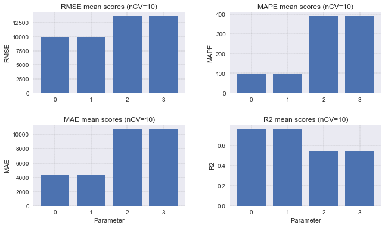

```
10 fold cross validation average scores of the best Estimator found by GridSearchCV

The average MAE for all cv folds is: 			 4416.6
The average MAE percentage (MAPE) for all cv folds is: 	 99.921
The average RMSE for all cv folds is: 			 9919.0
The average R2 for all cv folds is: 			 0.76118
Cross Validation Fold Mean Error Scores
           MAE        MAPE          RMSE        R2
0  4098.359489   98.726065   8581.261455  0.772731
1  4685.746260   99.973303  11072.603042  0.753215
2  3922.489710   98.226646   8411.785365  0.726033
3  4614.297659  109.343173  11063.455135  0.762239
4  4372.485514  105.662612   9507.122868  0.719193
5  4409.979913  100.429447   9487.563796  0.827837
6  4410.891615  101.677825   9503.267695  0.778887
7  4576.155879   89.632866  10226.837357  0.748977
8  4484.167756   97.134626   9673.490120  0.789402
9  4591.753411   98.404383  11662.612173  0.733252
```

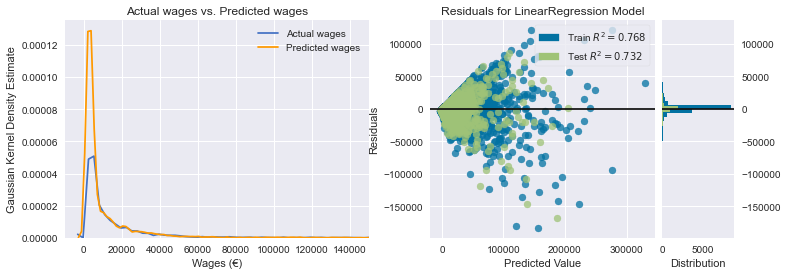

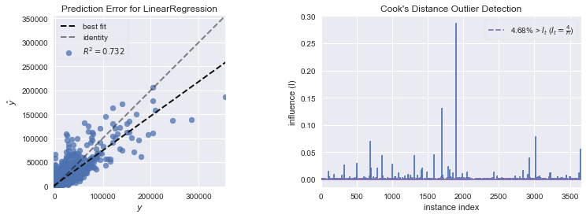

```
Wall time: 10.3 s
```

```python
%%time
import warnings
warnings.filterwarnings('ignore')

from sklearn.linear_model import LinearRegression

linreg = LinearRegression()
parameters = {'normalize':(True,False), 'fit_intercept':(True,False)}

m = evaluate_reg_model_performance('Linear Reg',parameters,linreg,'RMSE',X_reg_train,y_reg_train,X_reg_test,y_reg_test,nCV=10)
model_reg_stats = model_reg_stats.append(m[0])
model_reg_yhat = model_reg_yhat.append(m[1])
```

### 2. Lasso Regression

```
Best parameters set found:
{'alpha': 0.1, 'selection': 'cyclic', 'warm_start': True}

Mean score summary of each gridsearch estimator executed
```

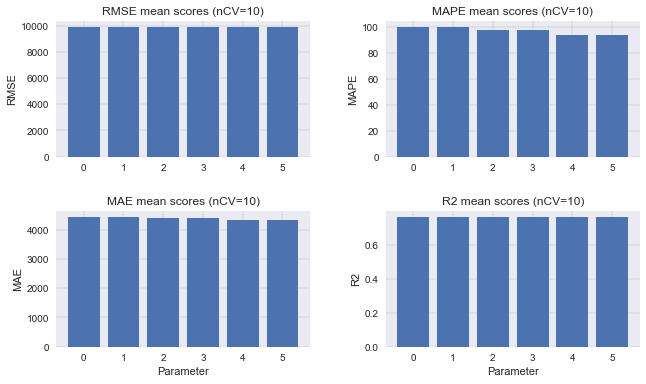

```
10 fold cross validation average scores of the best Estimator found by GridSearchCV

The average MAE for all cv folds is: 			 4385.8
The average MAE percentage (MAPE) for all cv folds is: 	 97.967
The average RMSE for all cv folds is: 			 9916.9
The average R2 for all cv folds is: 			 0.76127
Cross Validation Fold Mean Error Scores
           MAE        MAPE          RMSE        R2
0  4072.485542   97.032897   8581.440151  0.772722
1  4656.643239   97.998602  11063.885963  0.753603
2  3896.549446   96.422252   8417.011093  0.725693
3  4583.224804  107.591592  11065.380608  0.762156
4  4331.169610  103.105043   9490.906427  0.720150
5  4378.801318   98.427827   9478.440533  0.828167
6  4375.039173   99.310920   9506.573769  0.778733
7  4549.558068   88.232205  10227.643063  0.748937
8  4448.591612   94.988311   9668.982907  0.789598
9  4565.855218   96.565313  11668.424758  0.732986
```

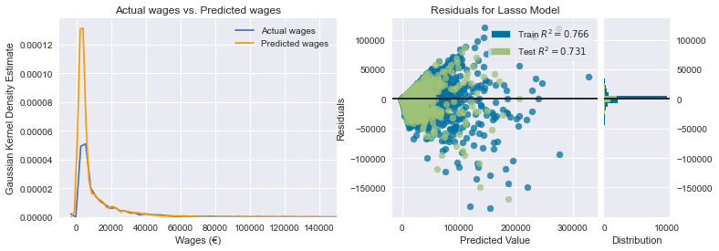

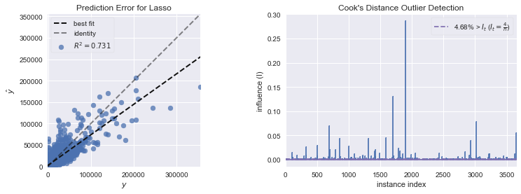

```
Wall time: 6.57 s
```

```python
%%time
from sklearn.linear_model import Lasso

reg = Lasso(fit_intercept=True, normalize=True,copy_X=True
          , max_iter=10000, precompute=True, tol=0.0001, random_state=45)

#Test parameters
alpha = [0.001, 0.1, 1]
selection = ['cyclic','random']
warm_start = [True]
parameters = {'alpha': alpha, 'selection': selection, 'warm_start': warm_start}

m = evaluate_reg_model_performance('Lasso Reg',parameters,reg,'RMSE',X_reg_train,y_reg_train,X_reg_test,y_reg_test,nCV=10)
model_reg_stats = model_reg_stats.append(m[0])
model_reg_yhat['Lasso Reg'] = m[1].copy()
```